# 647Project_Clustering

Stephen Cho, Minjee Kim

2024-11-18

## Data Cleaning

This step was already performed during the EDA process; first, we added a new variable, ‘Duration’.

```
##     Min.  1st Qu.   Median     Mean  3rd Qu.     Max.
##    0.017    7.650   12.700   17.238   20.683 5743.917
```

```r
duration_limits <- quantile(data$Duration, probs = c(0.25, 0.75), na.rm = TRUE)
duration_iqr <- IQR(data$Duration, na.rm = TRUE)
distance_limits <- quantile(data$trip_distance, probs = c(0.25, 0.75), na.rm = TRUE)
distance_iqr <- IQR(data$trip_distance, na.rm = TRUE)

data <- data %>%
  filter(
    Duration >= (duration_limits[1] - 1.5 * duration_iqr) & Duration <= (duration_limits[2] + 1.5 * duration_iqr),
    trip_distance >= (distance_limits[1] - 1.5 * distance_iqr) & trip_distance <= (distance_limits[2] + 1.5 * distance_iqr)
  )

dim(data)
```

```
## [1] 859762     25
```

```r
summary(data$Duration)
```

```
##     Min.  1st Qu.   Median     Mean  3rd Qu.     Max.
##  0.01667  7.00000 11.16667 12.53735 16.75000 40.23333
```

Around 140,000 data points were filtered out, resulting in a more reasonable summary for Duration.

# 2. Pickup demands

```r
pickup_data <- data %>% select(PU_Longitude, PU_Latitude, tpep_pickup_datetime, trip_id)

pickup_data <- pickup_data %>%
  mutate(
    pickup_hour = hour(tpep_pickup_datetime),
    pickup_day = wday(tpep_pickup_datetime, label = TRUE)
  )

hourly_demand <- pickup_data %>%
  group_by(PU_Longitude, PU_Latitude, pickup_hour, pickup_day) %>%
  summarize(demand = n(), .groups = "drop")

demand_matrix <- hourly_demand %>%
  unite("location", PU_Longitude, PU_Latitude, remove = FALSE) %>% # Combine coordinates for unique location ID
  pivot_wider(names_from = c(pickup_hour, pickup_day), values_from = demand, values_fill = 0)

### temporal
temporal_data <- as.matrix(demand_matrix[, -c(1:3)])

wavelet_coeffs <- apply(temporal_data, 1, function(row) {
  dwt(as.numeric(row), filter = "haar")  # Haar wavelet as an example
})

wavelet_matrix <- do.call(rbind, lapply(wavelet_coeffs, function(x) x@W))  # Extract wavelet coefficients
```

Finally, we can create the graph and minimum spanning tree:

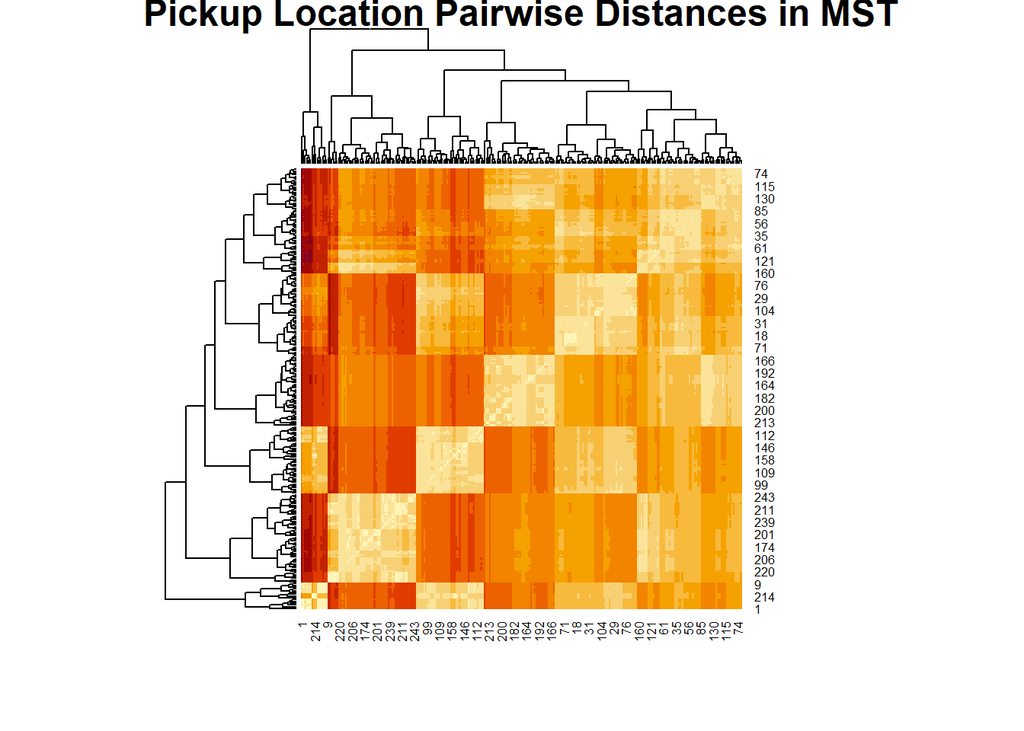

```r
library(igraph)
library(geosphere)

distances <- distm(cbind(demand_matrix$PU_Longitude, demand_matrix$PU_Latitude))
# edge list
edge_list <- which(lower.tri(distances), arr.ind = TRUE)  # Get row and column indices
edge_weights <- distances[lower.tri(distances)]  # Corresponding weights

# creating the graph
spatial_graph <- graph_from_edgelist(edge_list, directed = FALSE)
E(spatial_graph)$weight <- edge_weights

# creating minimum spanning tree
mst_pickup <- mst(spatial_graph, weights = E(spatial_graph)$weight)
shortest_path_distances <- distances(mst_pickup, weights = E(mst_pickup)$weight)
dist_matrix <- as.dist(shortest_path_distances)

heatmap(as.matrix(dist_matrix), main = "Pickup Location Pairwise Distances in MST")
```

```r
hc <- hclust(dist_matrix, method = "ward.D2")
num_clusters <- 5
spatial_clusters <- cutree(hc, k = num_clusters)

demand_matrix$spatial_cluster <- spatial_clusters
merged_data <- inner_join(pickup_data, demand_matrix, by = c("PU_Longitude", "PU_Latitude"))
```

We can get a heatmap of pairwise distances of pickup locations,

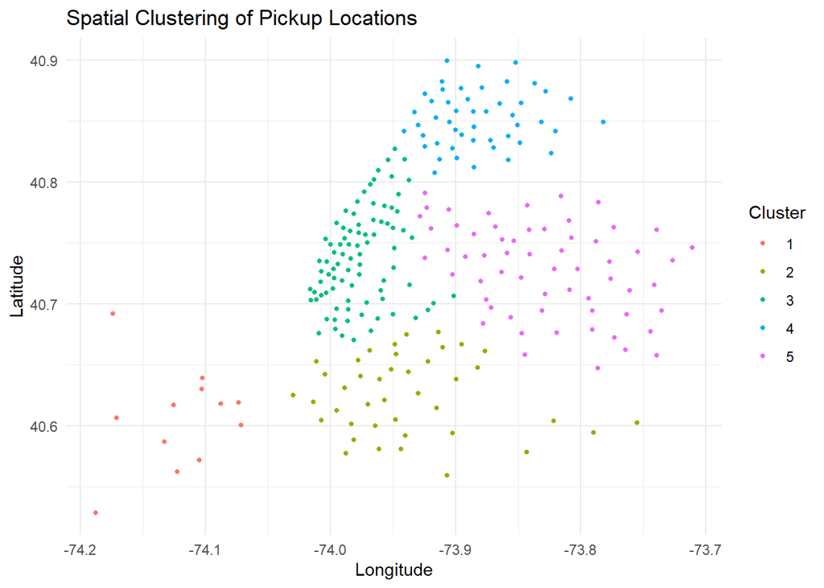

```r
ggplot(demand_matrix, aes(x = PU_Longitude, y = PU_Latitude, color = factor(spatial_cluster))) +
  geom_point(size = 1) +
  labs(
    title = "Spatial Clustering of Pickup Locations",
    x = "Longitude",
    y = "Latitude",
    color = "Cluster"
  ) +
  theme_minimal()
```

and eventually a visualization of spatial clusters of pickup locations in NYC.

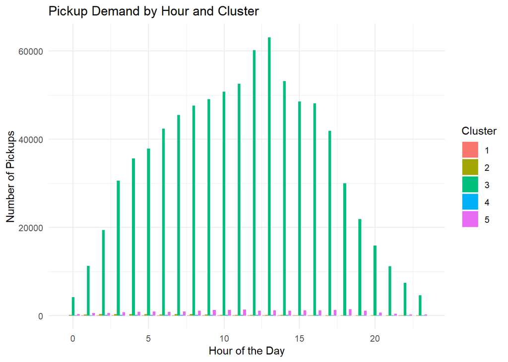

```r
ggplot(merged_data, aes(x = pickup_hour, fill = factor(spatial_cluster))) +
  geom_bar(position = "dodge") +
  labs(
    title = "Pickup Demand by Hour and Cluster",
    x = "Hour of the Day",
    y = "Number of Pickups",
    fill = "Cluster"
  ) +
  theme_minimal()
```

Lastly, we combine the pickup hour as a factor to visualize the pickup demand by hour and cluster.

#3. Drop-off Demands

We can do the same for drop-off portion of the data:

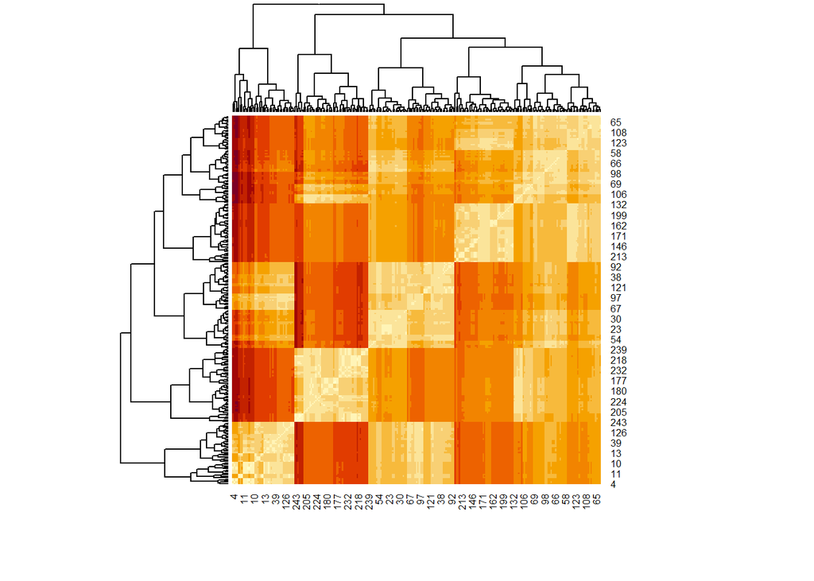

```r
dropoff_data <- data %>% select(DO_Longitude, DO_Latitude, tpep_dropoff_datetime, trip_id)

dropoff_data <- dropoff_data %>%
  mutate(
    dropoff_hour = hour(tpep_dropoff_datetime),
    dropoff_day = wday(tpep_dropoff_datetime, label = TRUE)
  )

hourly_demand_dropoff <- dropoff_data %>%
  group_by(DO_Longitude, DO_Latitude, dropoff_hour, dropoff_day) %>%
  summarize(demand = n(), .groups = "drop")

demand_matrix_dropoff <- hourly_demand_dropoff %>%
  unite("location", DO_Longitude, DO_Latitude, remove = FALSE) %>%
  pivot_wider(names_from = c(dropoff_hour, dropoff_day), values_from = demand, values_fill = 0)

temporal_data_dropoff <- as.matrix(demand_matrix_dropoff[, -c(1:3)])

wavelet_coeffs_dropoff <- apply(temporal_data_dropoff, 1, function(row) {
  dwt(as.numeric(row), filter = "haar")
})

wavelet_matrix_dropoff <- do.call(rbind, lapply(wavelet_coeffs_dropoff, function(x) x@W))

distances_dropoff <- distm(cbind(demand_matrix_dropoff$DO_Longitude, demand_matrix_dropoff$DO_Latitude))
edge_list_dropoff <- which(lower.tri(distances_dropoff), arr.ind = TRUE)
edge_weights_dropoff <- distances_dropoff[lower.tri(distances_dropoff)]

spatial_graph_dropoff <- graph_from_edgelist(edge_list_dropoff, directed = FALSE)
E(spatial_graph_dropoff)$weight <- edge_weights_dropoff

mst_dropoff <- mst(spatial_graph_dropoff, weights = E(spatial_graph_dropoff)$weight)
shortest_path_distances_dropoff <- distances(mst_dropoff, weights = E(mst_dropoff)$weight)
dist_matrix_dropoff <- as.dist(shortest_path_distances_dropoff)

heatmap(as.matrix(dist_matrix_dropoff))
```

```r
hc_dropoff <- hclust(dist_matrix_dropoff, method = "ward.D2")
num_clusters <- 5
spatial_clusters_dropoff <- cutree(hc_dropoff, k = num_clusters)

demand_matrix_dropoff$spatial_cluster <- spatial_clusters_dropoff
merged_data_dropoff <- inner_join(dropoff_data, demand_matrix_dropoff, by = c("DO_Longitude", "DO_Latitude"))
```

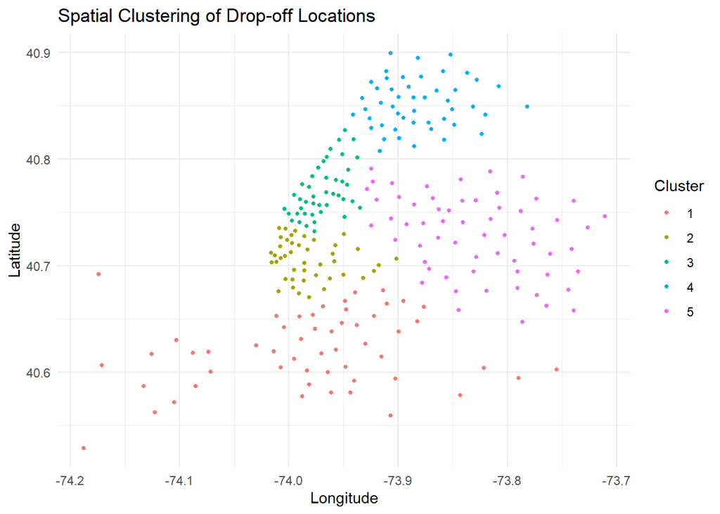

```r
ggplot(demand_matrix_dropoff, aes(x = DO_Longitude, y = DO_Latitude, color = factor(spatial_cluster))) +
  geom_point(size = 1) +
  labs(
    title = "Spatial Clustering of Drop-off Locations",
    x = "Longitude",
    y = "Latitude",
    color = "Cluster"
  ) +
  theme_minimal()
```

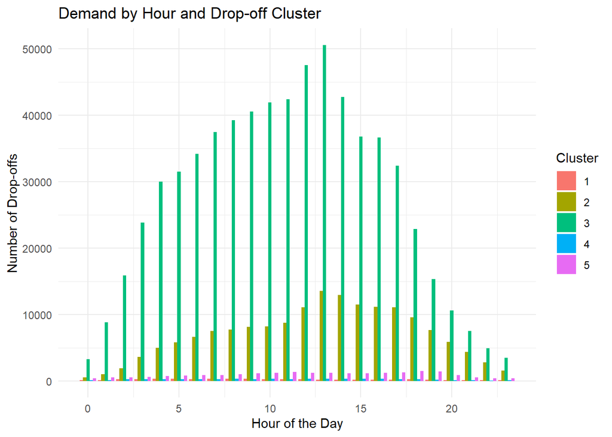

```r
ggplot(merged_data_dropoff, aes(x = dropoff_hour, fill = factor(spatial_cluster))) +
  geom_bar(position = "dodge") +
  labs(
    title = "Demand by Hour and Drop-off Cluster",
    x = "Hour of the Day",
    y = "Number of Drop-offs",
    fill = "Cluster"
  ) +
  theme_minimal()
```

#4. Matching the clusters

Lastly, we connect the clusters to further analyze the traffic flow.

```r
traffic_data <- data %>%
  left_join(merged_data, by = c("trip_id")) %>%
  left_join(merged_data_dropoff, by = c("trip_id"))

traffic_flow <- traffic_data %>%
  group_by(spatial_cluster.x, spatial_cluster.y) %>%
  summarize(trip_count = n(), .groups = "drop") %>%
  arrange(desc(trip_count))

library(ggraph)
traffic_flow$trip_count <- round(traffic_flow$trip_count)
flow_graph <- graph_from_data_frame(d = traffic_flow, directed = TRUE)
```

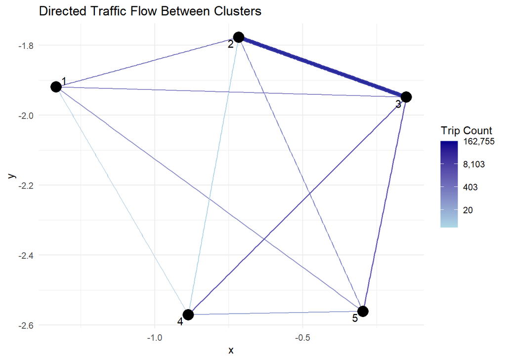

```r
ggraph(flow_graph, layout = "fr") +
  geom_edge_link(aes(width = trip_count, color = trip_count), alpha = 0.8) +
  geom_node_point(size = 5) +
  geom_node_text(aes(label = name), repel = TRUE) +
  scale_edge_color_gradient(
    low = "lightblue",
    high = "darkblue",
    trans = "log",
    labels = scales::comma  # Keep original counts formatted with commas
  ) +
  scale_edge_width(range = c(0.5, 2), guide = "none") +
  labs(
    title = "Directed Traffic Flow Between Clusters",
    edge_color = "Trip Count"
  ) +
  theme_minimal()
```